# Servikal kanser verisinde sınıflandırma algoritmalarının kiyaslanması

Öğrenci: Fatih Ekici

Öğretim Görevlisi: Deniz İnan

27 Ocak 2021

Abstract

Bu döküman Doç.Dr. Deniz İnan tarafından verilen IST4034.1 kodlu Veri Madenciliği dersi finali için hazırlanmıştır. Veri kaynağı: [UCİ](https://archive.ics.uci.edu/ml/datasets/Cervical+cancer+%28Risk+Factors%29#)

# Veri hakkında temel bilgiler

Veri Venezuela, Caracas’taki ’Hospital Universitario da toplandı. Veri seti 858 hastanın demografik bilgilerini, alışkanlıklarını ve geçmiş tıbbi kayıtlarını içerir.Veri seti hastaların rahim ağzı kanseri var mı yok mu şeklinde bilgi içermekte hedef değişkenimiz ise biyopsi sonucu Bu sonuca göre hasta veya hasta değil bilgisine erişiyoruz.

## Veri künyesi

| veri tipi | değişken ismi | değişken açıklaması |
| --- | --- | --- |
| int | Age | Yaş |
| int | Number of sexual partners | Cinsel partner sayisi |
| int | First sexual intercourse | ilk cinsel ilişki |
| int | Num of pregnancies | gebelik sayisi |
| bool | Smokes | Sigara kullanıyor mu? |
| bool | Smokes (years) | Sigara kullaniyor ise kaç yıldır kullanıyor? |
| bool | Smokes (packs/year) | yıllık sigara paketi sayisi |
| bool | Hormonal Contraceptives | Hormonal Kontraseptifler |
| int | Hormonal Contraceptives (years) | Hormonal Kontraseptifler(Yıllık) |
| bool | IUD | Hormon salıcı kullanıyor mu? |
| int | IUD (years) | Yılda kaç adet IUD kullanıyor? |
| bool | STDs | Cinsel hastalığı var mı? |
| int | STDs (number) | Kaç adet cinsel hastalığı var |
| bool | STDs:condylomatosis | Hpv sebepli siğil |
| bool | STDs:cervical condylomatosis | Hpv sebepli rahim ağzı siğili |
| bool | STDs:vaginal condylomatosis | Vajinal bölge siğil |
| bool | STDs:vulvo-perineal condylomatosis | Dış genital bölge siğili |
| bool | STDs:syphilis | sifiliz |
| bool | STDs:pelvic inflammatory disease | pelvik inflamatuar hastalık |
| bool | STDs:genital herpes | genital herpes |
| bool | STDs:molluscum contagiosum | molluscum contagiosum |
| bool | STDs:AIDS | AIDS |
| bool | STDs:IHV | HiV |
| bool | STDs:Hepatitis B | Hepatitis B |
| bool | STDs:HPV | HPV |
| int | STDs: Number of diagnosis | Tanı sayısı |
| int | STDs: Time since first diagnosis | İlk teşhisten itibaren geçen süre |
| int | STDs: Time since last diagnosis | Son teşhisten bu yana geçen süre |
| bool | Dx:Cancer | Kanser |
| bool | Dx:CIN | CIN |
| bool | Dx:HPV | HPV |
| bool | Dx | Dx |
| bool | Hinselmann | Hinselmann |
| bool | Schiller | Schiller(test) |
| bool | Citology | Sitoloji(test) |
| bool | Biopsy | Biyopsi(test) |

# Veri analizine giriş

**Yüklenmesi gereken paketler**

**Paralel hesaplama**

```r
library(doParallel)
cl <- makePSOCKcluster(7)

registerDoParallel(cl)
```

**Verinin Yüklenmesi**

```r
cancer_df <- read_csv("Cervical_cancer_(Risk_Factors)/risk_factors_cervical_cancer.csv",
    na = "?")
cancer_df %>% top_n(10)
```

| Age | Number of sexual partners | First sexual intercourse | Num of pregnancies | Smokes | Smokes (years) | Smokes (packs/year) | Hormonal Contraceptives | Hormonal Contraceptives (years) | IUD | IUD (years) | STDs | STDs (number) | STDs:condylomatosis | STDs:cervical condylomatosis | STDs:vaginal condylomatosis | STDs:vulvo-perineal condylomatosis | STDs:syphilis | STDs:pelvic inflammatory disease | STDs:genital herpes | STDs:molluscum contagiosum | STDs:AIDS | STDs:HIV | STDs:Hepatitis B | STDs:HPV | STDs: Number of diagnosis | STDs: Time since first diagnosis | STDs: Time since last diagnosis | Dx:Cancer | Dx:CIN | … |
| --- | --- | --- | --- | --- | --- | --- | --- | --- | --- | --- | --- | --- | --- | --- | --- | --- | --- | --- | --- | --- | --- | --- | --- | --- | --- | --- | --- | --- | --- | --- |
| 51 | 3 | 17 | 6 | 1 | 34.000000 | 3.4000000 | 0 | 0.00 | 1 | 7 | 0 | 0 | 0 | 0 | 0 | 0 | 0 | 0 | 0 | 0 | 0 | 0 | 0 | 0 | 0 | NA | NA | 0 | 0 | … |
| 40 | 1 | 18 | 1 | 0 | 0.000000 | 0.0000000 | 1 | 0.25 | 0 | 0 | 1 | 2 | 1 | 0 | 0 | 1 | 0 | 0 | 0 | 0 | 0 | 0 | 0 | 0 | 1 | 2 | 2 | 0 | 0 | … |
| 40 | 1 | 20 | 2 | 0 | 0.000000 | 0.0000000 | 1 | 15.00 | 0 | 0 | 0 | 0 | 0 | 0 | 0 | 0 | 0 | 0 | 0 | 0 | 0 | 0 | 0 | 0 | 0 | NA | NA | 1 | 0 | … |
| 37 | 2 | 18 | NA | 0 | 0.000000 | 0.0000000 | 0 | 0.00 | NA | NA | 1 | 1 | 0 | 0 | 0 | 0 | 0 | 0 | 0 | 0 | 0 | 1 | 0 | 0 | 1 | 15 | 15 | 0 | 1 | … |
| 37 | 3 | 19 | 3 | 1 | 12.000000 | 6.0000000 | 1 | 13.00 | 0 | 0 | 0 | 0 | 0 | 0 | 0 | 0 | 0 | 0 | 0 | 0 | 0 | 0 | 0 | 0 | 0 | NA | NA | 0 | 0 | … |
| 38 | 2 | 15 | 4 | 0 | 0.000000 | 0.0000000 | 1 | 16.00 | 0 | 0 | 0 | 0 | 0 | 0 | 0 | 0 | 0 | 0 | 0 | 0 | 0 | 0 | 0 | 0 | 0 | NA | NA | 1 | 0 | … |
| 33 | 1 | 29 | 2 | 0 | 0.000000 | 0.0000000 | 1 | 0.50 | 0 | 0 | 0 | 0 | 0 | 0 | 0 | 0 | 0 | 0 | 0 | 0 | 0 | 0 | 0 | 0 | 0 | NA | NA | 0 | 0 | … |
| 35 | 5 | 11 | NA | 1 | 15.000000 | 15.0000000 | 1 | 14.00 | 0 | 0 | 0 | 0 | 0 | 0 | 0 | 0 | 0 | 0 | 0 | 0 | 0 | 0 | 0 | 0 | 0 | NA | NA | 0 | 0 | … |
| 38 | 3 | 18 | 4 | 0 | 0.000000 | 0.0000000 | 1 | 10.00 | 1 | 2 | 0 | 0 | 0 | 0 | 0 | 0 | 0 | 0 | 0 | 0 | 0 | 0 | 0 | 0 | 0 | NA | NA | 0 | 0 | … |
| 30 | NA | 13 | 3 | 1 | 22.000000 | 3.3000000 | 0 | 0.00 | 0 | 0 | 1 | 1 | 0 | 0 | 0 | 0 | 0 | 0 | 0 | 0 | 0 | 1 | 0 | 0 | 1 | 3 | 3 | 0 | 0 | … |

[output cut: 45 more lines]

Eksik veri sayımızı değişkenlerin temel istatistiklerini inceleyelim.

```r
#skimr paketi veriyi summary()'Ye kıyasla daha güzel bir format ile gösterir.

cancer_df %>% janitor::clean_names() %>% skimr::skim()
```

```
-- Data Summary ------------------------
                           Values
Name                       Piped data
Number of rows             858
Number of columns          36
_______________________
Column type frequency:
  numeric                  36
________________________
Group variables            None

-- Variable type: numeric ----------------------------------------------------------------------
# A tibble: 36 x 11
   skim_variable                       n_missing complete_rate     mean     sd    p0   p25   p50
 * <chr>                                   <int>         <dbl>    <dbl>  <dbl> <dbl> <dbl> <dbl>
```

[output cut: 74 more lines]

## Eksik ve Hatalı gözlemlerin silinmesi.

```r
sum(is.na(cancer_df))
```

```
[1] 3622
```

Toplam 3622 adet eksik gözlem bulunmakta. Verideki eksik değişkenler gerçeken bilinmediği için değil herhangi bir değer girilmesinin anlamsız kalınmasından kaynaklı eksikler.STD’si bulunmayan bir kişinin ilk teşhis tarihi bulunmayacağından dolayı ilgili kısım boş kalakacaktır. Sonuç olarak eksik verileri yapacağımız modellerin gereksinimleri sebebiyle doldurmalıyız veya bazı gözlem veya değişkenleri silmeliyiz. Eksik gözlemleri araştıralım.

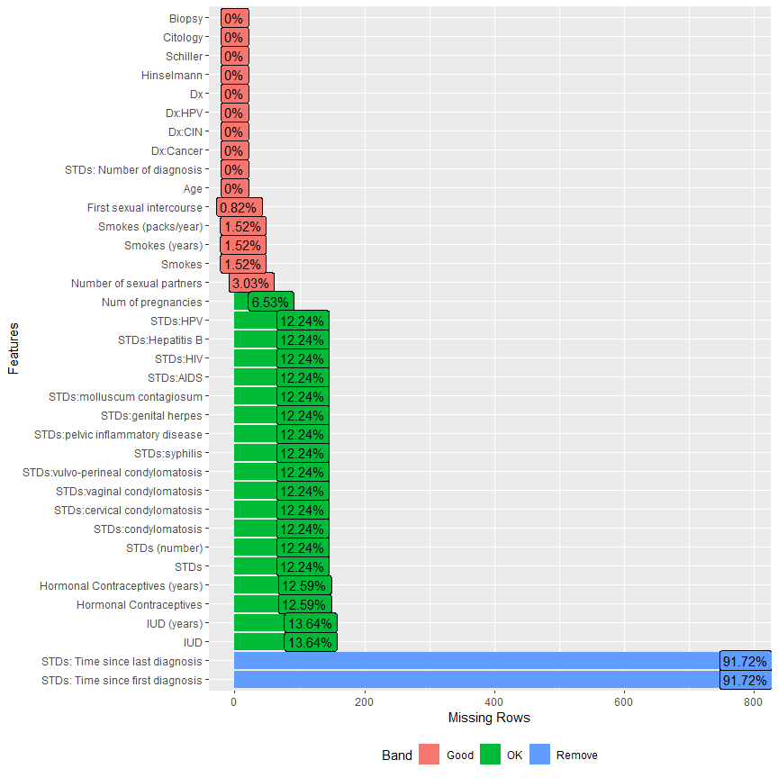

```r
DataExplorer::plot_missing(cancer_df)
```

En büyük problem STDs kısmında gözüküyor bakalım.

```r
cancer_df %>% filter(STDs!=0) %>% select(`STDs: Time since first diagnosis`,`STDs: Time since last diagnosis`) %>% nrow()-
  cancer_df %>% filter(STDs!=0) %>% select(`STDs: Time since first diagnosis`,`STDs: Time since last diagnosis`) %>%na.omit() %>%  nrow()
```

```
[1] 8
```

Cinsel hastalığı olan kişiler için sadece 8 kişinin teşhiş bilgisi tanımlanmamış Kalan herkesin bilgisi bulunmakta, Yani aslında eksik sayısı 8 diyebiliriz.

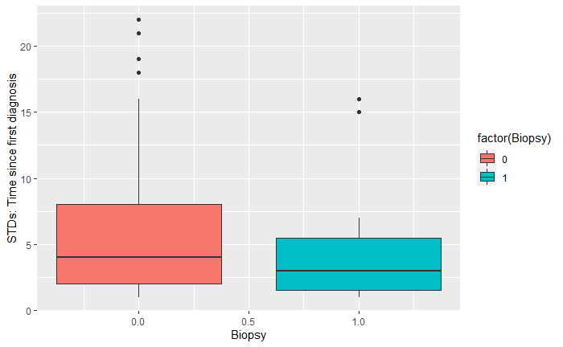

```r
#teşhis süresinden geçen zamanın biopsy sürecine olan etkisini bakalım.
cancer_df[c("STDs: Time since first diagnosis","STDs: Time since last diagnosis","Biopsy")] %>% ggplot(aes(y=`STDs: Time since first diagnosis`,x=`Biopsy`)) +geom_boxplot(aes(fill=factor(Biopsy)))
```

```r
cancer_df %>% group_by(`STDs: Time since first diagnosis`) %>% summarise(n=n())
```

| STDs: Time since first diagnosis | n |
| --- | --- |
| 1 | 15 |
| 2 | 9 |
| 3 | 10 |
| 4 | 6 |
| 5 | 4 |
| 6 | 3 |
| 7 | 5 |
| 8 | 3 |
| 9 | 1 |
| 10 | 1 |

[output cut: 9 more lines]

Boxplot aykırı değerler sebebiyle pek net olmayan bir sonuç vermiştir. ilk 3 yılın toplam dolu gözlem sayısının yarısına yakın bir miktarına eşit olduğunu görmekteyiz.Açıkçası modele yüksek miktarda farkı olan bir değişken olmaması sebebiyle gruplara ayırıp NA’ları doldurmayı gereksiz buluyorum. Biopsi sonucuna asıl etki edenin gerekenin STD olup olmadığı veya kaç adet STD sahibi olduğudur. Bu sebeble bu değişkenleri silelim.

```r
cancer_df %>% select(-c("STDs: Time since first diagnosis","STDs: Time since last diagnosis"))->cancer_df
```

Ayrıca verideki smokes pacts/year değişkeni hatalı bilgi içermektedir. Bu sebeble bu değişkenide kaldıralım.

```r
cancer_df %>% select(-c(`Smokes (packs/year)`))->cancer_df
cancer_df %>% mutate(`Smokes (years)`=round(`Smokes (years)`),
                     `Hormonal Contraceptives (years)`=round(`Hormonal Contraceptives (years)`,2))->cancer_df
```

```r
#binary fonksiyonu
is.binary<-function(x){
  return(ifelse((na.omit(x) %>% unique() %>% length())<3,TRUE,FALSE))
}
#dönüştürme fonksiyonu
cancer_df %>%  mutate_if(is.binary,as.factor)->cancer_df

cancer_df<-na.omit(cancer_df)
cancer_df$`STDs:cervical condylomatosis`<-as.numeric(cancer_df$`STDs:cervical condylomatosis`)
cancer_df$`STDs:AIDS`<-as.numeric(cancer_df$`STDs:AIDS`)
```

## Dengesiz dağılmış veri problemi

```r
cancer_df %>% select(Biopsy) %>% group_by(Biopsy) %>% summarise(n=n())
```

| Biopsy | n |
| --- | --- |
| 0 | 623 |
| 1 | 45 |

Verimizde 623 adet biyopsi sonucu 0 çıkan hasta var iken 45 adet 1(pozitif) çıkan hasta bu durumda sınıflandırma dengesiz gözlem problemi ile karşılaşıyoruz. Burda yapabileceğimiz şeyler metriklerimizi kappa ve auc alarak devam etmek ,undersampling yapmak, veya smote ile sentetik yeni gözlemler oluşturarak verimizi çoğaltmaktır.

# Train-test ayrımı

```r
set.seed(5)
split = sample.split(cancer_df$Biopsy, SplitRatio = 0.50)

train = subset(cancer_df,split == TRUE)
colnames(train)<-make.names(colnames(train))
test = subset(cancer_df,split == FALSE)
colnames(test)<-make.names(colnames(test))
```

# Model oluşturma

Burada pek çok model oluşturup bu modelleri test edeceğiz. burada bagging ile başlayıp veriyi sanallaştırıp performansı test edeceğim iyi sonuç verirse diğer modellerde de simüle veri kullanacaktır.

## Bagging modeli

Mtry değeri bağımsız değişken sayısına eşitlediğimizde bagging yapmamıza olanak sağlıyor.

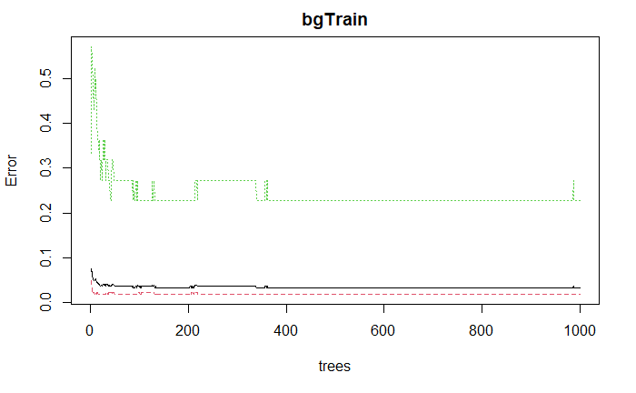

```r
set.seed(6)
bgTrain<-randomForest(Biopsy~.,data = train,
                      importance=TRUE,
                      mtry=ncol(train)-1,
                      ntree=1000,
                      metric="ROC"
                       )
plot(bgTrain)
```

```r
library(caret)
set.seed(99)
confusionMatrixBagging<-confusionMatrix(predict(bgTrain,test),test$Biopsy,positive = "1")
confusionMatrixBagging
```

```
Confusion Matrix and Statistics

          Reference
Prediction   0   1
         0 300   9
         1  11  14

               Accuracy : 0.9401
                 95% CI : (0.909, 0.963)
    No Information Rate : 0.9311
    P-Value [Acc > NIR] : 0.3023

                  Kappa : 0.5511

 Mcnemar's Test P-Value : 0.8231

            Sensitivity : 0.60870
            Specificity : 0.96463
         Pos Pred Value : 0.56000
         Neg Pred Value : 0.97087
             Prevalence : 0.06886
         Detection Rate : 0.04192
   Detection Prevalence : 0.07485
      Balanced Accuracy : 0.78666

       'Positive' Class : 1
```

```r
confusionMatrixBagging$byClass %>% t() %>% magrittr::set_rownames('Bagging')-> resultBagging #sonuçları kıyaslamak için

print(data.frame(resultBagging))
```

|  | Sensitivity | Specificity | Pos.Pred.Value | Neg.Pred.Value | Precision | Recall | F1 | Prevalence | Detection.Rate | Detection.Prevalence | Balanced.Accuracy |
| --- | --- | --- | --- | --- | --- | --- | --- | --- | --- | --- | --- |
| Bagging | 0.6086957 | 0.9646302 | 0.56 | 0.9708738 | 0.56 | 0.6086957 | 0.5833333 | 0.06886228 | 0.04191617 | 0.0748503 | 0.7866629 |

```r
NA
```

Oversampling ile daha iyi bir sonuç almayı deniyelim.

### Oversampling

Rose paketi ile oversampling yapıyorum.

```r
library(ROSE)
set.seed(100)
ovun.sample(Biopsy~., data=train,method = "over",N=624)$data->overtrain #N üretilmek istenen düsük gözlemin sayısı iki katını vererek eşit sayısa getiriyoruz.
rfOVerTrain<-randomForest(Biopsy~.,data = train,
                      importance=TRUE,
                      mtry=ncol(train)-1
                       )
table(overtrain$Biopsy)
```

```
  0   1
312 312
```

```r
confusionMatrix(predict(rfOVerTrain,test),test$Biopsy,positive = "1")
```

```
Confusion Matrix and Statistics

          Reference
Prediction   0   1
         0 301   9
         1  10  14

               Accuracy : 0.9431
                 95% CI : (0.9126, 0.9654)
    No Information Rate : 0.9311
    P-Value [Acc > NIR] : 0.2287

                  Kappa : 0.5652

 Mcnemar's Test P-Value : 1.0000

            Sensitivity : 0.60870
            Specificity : 0.96785
         Pos Pred Value : 0.58333
         Neg Pred Value : 0.97097
             Prevalence : 0.06886
         Detection Rate : 0.04192
   Detection Prevalence : 0.07186
      Balanced Accuracy : 0.78827

       'Positive' Class : 1
```

Model gayet mantıklı sonuçlar vermesi sebebiyle Tune işlemi yapmıyorum.

### Model iyileştirme

```r
#hedef değişkenin levelleri numeric olmamak zoruda bu sebeble veriyi yeniliyoruz.
train->train2
train2$Biopsy<-ifelse(train2$Biopsy==1,"YES","NO")
test->test2
test2$Biopsy<-ifelse(test2$Biopsy==1,"YES","NO")
test2$Biopsy<-as.factor(test2$Biopsy)
```

```r
#tekrarlı cross validasyon 10 fold 3 tekrar

control <- trainControl(method='repeatedcv',
                        number=10,
                        repeats=3
                      )
```

```r
modelcv<-train(
  factor(Biopsy) ~ .,
  data = train2,
  method = "treebag",
  trControl = control,
  nbagg = 200,
  control = rpart.control(minsplit = 2, cp = 0)
)
```

[output not shown]

```r
#confussion matrix yazarak model performansını test edelim.
test_x<-select(test2,-Biopsy)
confusionMatrixBaggingTune<-confusionMatrix(predict(modelcv,test2),test2$Biopsy,positive="YES")

confusionMatrixRandomForest$byClass %>%
  t() %>%
  magrittr::set_rownames('resultBaggingTune')-> resultBaggingTune#sonuçları kıyaslamak için

print(confusionMatrixBaggingTune)
print(resultBaggingTune)
```

[output not shown]

## Klasik Karar Ağacı(Decision Tree)

Klasik karar ağacı modeli için rpart paketini kullanalım.

```r
 tcTrain<-rpart(formula=Biopsy~., data=train2, control=rpart.control(minsplit=2, minbucket=1, cp=0.001))
print(tcTrain)
```

Basitçe modelimizi bu şekilde oluşturabiliyoruz.

```r
set.seed(102)
confusionMatrixTc<-confusionMatrix(predict(tcTrain,test2,type = "class"),test2$Biopsy,positive = "YES")

confusionMatrixTc$byClass %>% t() %>% magrittr::set_rownames('Decion Tree Clasic')-> resultTc #sonuçları kıyaslamak için
confusionMatrixTc
resultTc
```

[output not shown]

```r
rpart.plot::rpart.plot(x = tcTrain, yesno = 2, type = 0, extra = 0)
```

[output not shown]

## Karar ağacı modelini budayalım.

rpart paketi default ayarlarda en sade modeli oluşturacak şekilde ayarlanmıştır. Herhangi bir kompleksite parametresi girmeden verinin budanmış halini alabiliriz.

```r
tcTrainSimple<-rpart(formula = Biopsy~.,data = train,
               method = "class")

print(tcTrainSimple)
```

```r
rpart.plot::rpart.plot(x = tcTrainSimple, yesno = 2, type = 0, extra = 0)
```

[output not shown]

Mudanmış modelimiz hazır.

Model performasını inceleyelim.

```r
set.seed(107)
confusionMatrixTcsimple<-confusionMatrix(predict(tcTrainSimple,test,type = "class"),test$Biopsy,positive = "1")

confusionMatrixTcsimple$byClass %>% t() %>% magrittr::set_rownames('Simple Decion Tree Clasic')-> resultSimpleTc #sonuçları kıyaslamak için
confusionMatrixTcsimple
```

[output not shown]

## Random Forest

Daha önceden oluşturmuş olduğumuz bagging modelinde mtry değerini karekök olarak aldığımızda random forest modeli oluşmakta modelimizi oluşturalım.

```r
rfTrain<-randomForest(Biopsy~.,data = train,
                      importance=TRUE,
                      mtry=sqrt(ncol(train))
                       )
confusionMatrixRandomForest<-confusionMatrix(predict(rfTrain,test),test$Biopsy,positive = "1")

confusionMatrixRandomForest$byClass %>%
  t() %>%
  magrittr::set_rownames('RandomForest')-> resultRandomForest #sonuçları kıyaslamak için

print(confusionMatrixRandomForest)
print(data.frame(resultRandomForest))
```

[output not shown]

### model iyileştirme

```r
#hedef değişkenin levelleri numeric olmamak zoruda bu sebeble veriyi yeniliyoruz.
train->train2
train2$Biopsy<-ifelse(train2$Biopsy==1,"YES","NO")
test->test2
test2$Biopsy<-ifelse(test2$Biopsy==1,"YES","NO")
test2$Biopsy<-as.factor(test2$Biopsy)
```

```r
#tekrarlı cross validasyon 10 fold 3 tekrar

control <- trainControl(method='repeatedcv',
                        number=10,
                        repeats=3,
                        search = 'random')

set.seed(123)
#metriğimiz hata yapmayı cezalandıran "Roc" metriğini kullanacağız.
modelcv<-train(Biopsy~.,data = train2,
               methods="rf",
               metric="ROC",
               tuneLength  = 15,
               trControl=ctrl)
```

```r
#confussion matrix yazarak model performansını test edelim.
test_x<-select(test2,-Biopsy)
confusionMatrixRandomForest<-confusionMatrix(predict(modelcv,test2),test2$Biopsy,positive="YES")

confusionMatrixRandomForest$byClass %>%
  t() %>%
  magrittr::set_rownames('RandomForest')-> resultRandomForest #sonuçları kıyaslamak için
```

```r
#sonuçların gösterilmesi
print(confusionMatrixRandomForest)
print(data.frame(resultRandomForest))
```

[output not shown]

## Boosting

Boosting modeli

Boosting modeli hedef değişkenin 0-1 formatında olmasını istiyor factorden integer’a çevirelim.

```r
train$Biopsy<-as.integer(train$Biopsy)
ifelse(train2$Biopsy=="NO",0,1)->train$Biopsy
test$Biopsy<-as.integer(test$Biopsy)
ifelse(test2$Biopsy=="NO",0,1)->test$Biopsy
```

**Modeli oluşturalım.**

```r
library(gbm)
set.seed(1453)
gmb_train<-gbm(Biopsy~.,data=train,
               shrinkage = 0.01, #adım büyüklüğü ne kadar küçükse o kadar iyi ve fazla zaman
               distribution = "bernoulli",#sınıflandırma
               cv.folds = 5, #cross validasyon
               n.trees = 3000, #ağaç sayısı
               verbose = F
               )
```

```r
summary(gmb_train)
```

Model performasını inceleyelim.

```r
pred <- predict(gmb_train,newdata=test,
                              type = "response")
ifelse(pred>0.5,1,0)->pred
```

### Confussion Matrix

```r
confusionMatrixGBM<-confusionMatrix(factor(pred),factor(test$Biopsy),positive="1")

confusionMatrixGBM$byClass %>%
  t() %>%
  magrittr::set_rownames('GBM')-> resultGBM #sonuçları kıyaslamak için

confusionMatrixGBM
```

[output not shown]

## Lojistik regresyon

Yine Gbm ile lojistik regresyon modeli yapacağız.

```r
cancer_df$`STDs:cervical condylomatosis`<-as.numeric(cancer_df$`STDs:cervical condylomatosis`)
cancer_df$`STDs:AIDS`<-as.numeric(cancer_df$`STDs:AIDS`)

train %>% select(-c( STDs.pelvic.inflammatory.disease,STDs.cervical.condylomatosis,STDs.AIDS, STDs.Hepatitis.B))->train

apply(train, 2,function(x){
  length(unique(x))
})
train %>% mutate(Biopsy=as.numeric(Biopsy),
                 Biopsy=ifelse(Biopsy==1,0,1))->train
logTrain <- glm(formula=Biopsy ~ . , family = binomial(link='logit'),data = train)
```

```r
predGBM <- predict(logTrain,newdata=select(test,-Biopsy),type='response')

# Bu mdoel de olasılık çıktısı verdiği için dönüşüm yapıyoruz
predGBM<- ifelse(predGBM > 0.5,"Yes","No")
ifelse(test2$Biopsy=="NO",0,1)->test$Biopsy
confusionMatrixLOG<-confusionMatrix(factor(pred),factor(test$Biopsy),positive = "1")

confusionMatrixLOG$byClass %>%
  t() %>%
  magrittr::set_rownames('Lojistik regresyon')-> resultLog

confusionMatrixLOG
```

[output not shown]

# Model Sonuçları kıyaslaması

```r
ls(pattern = "^result")
rbind(resultTc,
resultSimpleTc,
resultBagging,
resultBaggingTune,
resultRandomForest,
resultLog) %>% data.frame() %>% arrange(-Sensitivity)
```

[output not shown]